# Yandex.Afisha Optimize Marketing Expenses Project

### Marketing

- How much money was spent? Overall/per source/over time.
- How much did customer acquisition from each of the sources cost?
- How worthwhile where the investments? (ROI).  
  Plot graphs to display how these metrics differ for various devices and ad sources and how they change in time.

```python
# Study how much money was spent.

# Overall costs
print('The overal costs for year is {} usd. '.format(costs['costs'].sum()))
```

```
The overal costs for year is 329131.62 usd.
```

```python
# The cost per source
costs_per_source = costs.groupby('source_id').agg({'costs':['mean', 'sum']}).reset_index()
costs_per_source.columns=['source_id', 'avg_monthly_costs', 'total_costs']
```

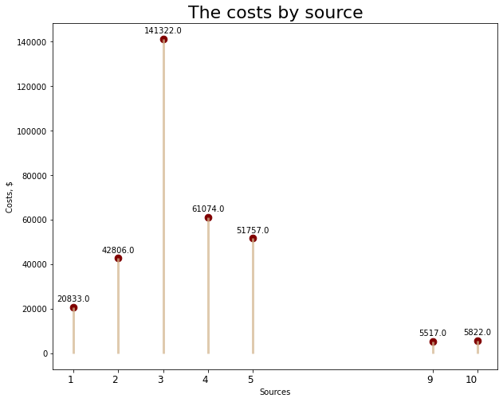

```python
fig, ax = plt.subplots(figsize=(10,8))
ax.vlines(x=costs_per_source.source_id, ymin=0, ymax=costs_per_source.total_costs, color='tan', alpha=0.7, linewidth=3)
ax.scatter(x=costs_per_source.source_id, y=costs_per_source.total_costs, s=75, color='maroon')
ax.set_title('The costs by source', fontdict={'size':22})
ax.set_ylabel('Costs, $')
ax.set_xlabel('Sources')
ax.set_xticks(costs_per_source.source_id)
ax.set_xticklabels(costs_per_source.source_id, fontdict={'horizontalalignment': 'right', 'size':12})
for row in costs_per_source.itertuples():
    ax.text(row.source_id, row.total_costs+2500, s=round(row.total_costs, 0),
            fontdict={'horizontalalignment': 'center','size':10})
plt.show()
```

As we can see, sources 6, 7, 8 have no costs, that is, they are free.

```python
# Study the costs per month by sources
costs['month_costs'] = costs['date_costs'].dt.strftime('%Y-%m')
costs_month_per_source = costs.pivot_table(index='month_costs', columns='source_id',
                                           values='costs', aggfunc='sum')
```

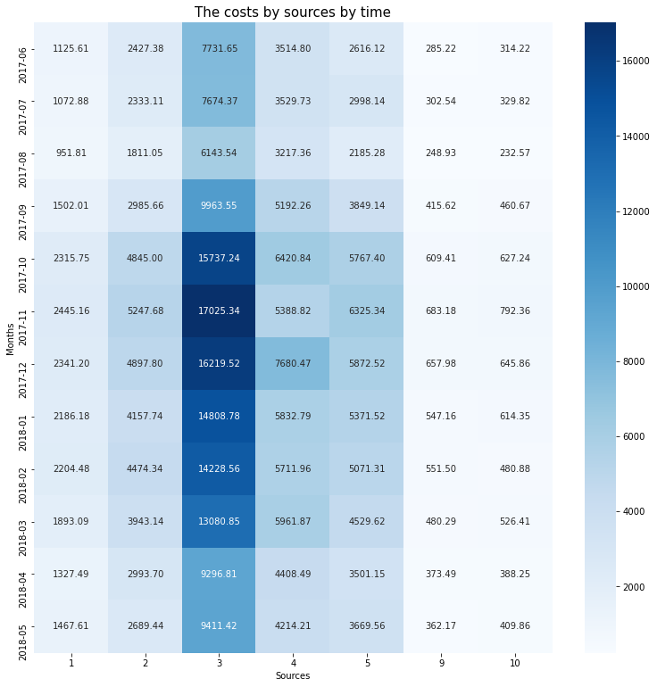

```python
plt.figure(figsize=(13,13))
sns.heatmap(costs_month_per_source, cmap='Blues', annot=True, fmt='.2f')
plt.title('The costs by sources by time', fontdict={'size':15})
plt.ylabel('Months')
plt.xlabel('Sources')
plt.show()
```

As we can see, the most expensive source number 3. Sources 9 and 10 are the least expensive.

```python
# Study how much customer acquisition from each of the sources cost
users_per_source = orders.groupby('source_id')['uid'].nunique()
users_per_source.name = 'n_customers'
costs = costs.join(users_per_source, on='source_id')
```

```python
costs_sources = costs.groupby('source_id').agg({'costs':'sum', 'n_customers':'max'}).reset_index()
costs_sources['cac'] = costs_sources['costs'] / costs_sources['n_customers']
```

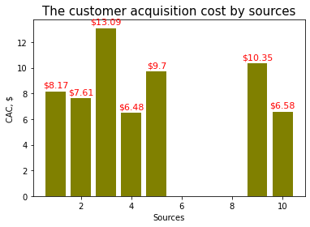

```python
fig, ax = plt.subplots()
rect=ax.bar(costs_sources['source_id'], costs_sources['cac'], color='olive')
ax.set_ylabel('CAC, $')
ax.set_xlabel('Sources')
ax.set_title('The customer acquisition cost by sources', fontdict={'size':15})
for row in costs_sources.itertuples():
    ax.text(row.source_id, row.cac+0.3, s='$'+str(round(row.cac, 2)),
            fontdict={'horizontalalignment': 'center','size':11, 'color':'red'})
plt.show()
```

> All the way I doubted that it could be rubles :)

The 3rd source leads in costs. Sources 6,7,8 do not require investment.

```python
roi_source = orders_sources[['source_id', 'arpu']]
costs_sources = costs_sources.set_index('source_id')
roi_source = roi_source.join(costs_sources, on='source_id')
costs_sources = costs_sources.reset_index()
```

```python
roi_source = roi_source.fillna(0)
roi_source['payoff'] = ((roi_source['arpu'] - roi_source['cac']) > 0)
```

```python
roi_source
```

|  | source_id | arpu | costs | n_customers | cac | payoff |
| --- | --- | --- | --- | --- | --- | --- |
| 0 | 1 | 14.25 | 20833.27 | 2551.0 | 8.166707 | True |
| 1 | 2 | 13.54 | 42806.04 | 5628.0 | 7.605906 | True |
| 2 | 3 | 5.39 | 141321.63 | 10795.0 | 13.091397 | False |
| 3 | 4 | 4.79 | 61073.60 | 9432.0 | 6.475148 | False |
| 4 | 5 | 4.74 | 51757.10 | 5337.0 | 9.697789 | False |
| 5 | 6 | 4.87 | 0.00 | 0.0 | 0.000000 | True |
| 6 | 7 | 4.54 | 0.00 | 0.0 | 0.000000 | True |
| 7 | 8 | 4.98 | 0.00 | 0.0 | 0.000000 | True |
| 8 | 9 | 3.60 | 5517.49 | 533.0 | 10.351764 | False |
| 9 | 10 | 2.76 | 5822.49 | 885.0 | 6.579085 | False |

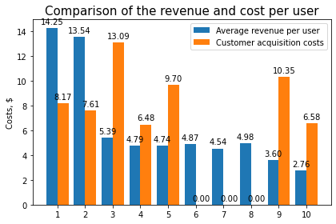

```python
# How worthwhile where the investments? (ROI).

labels = roi_source['source_id'].tolist()
arpu = roi_source['arpu'].tolist()
cac = roi_source['cac'].tolist()
x = np.arange(len(labels))  # the label locations
width = 0.4  # the width of the bars

fig, ax = plt.subplots()
rects1 = ax.bar(x - 0.5*width, arpu, width, label='Average revenue per user')
rects2 = ax.bar(x + 0.5*width, cac, width, label='Customer acquisition costs')

ax.set_ylabel('Costs, $')
ax.set_title('Comparison of the revenue and cost per user', fontdict={'size':15})
ax.set_xticks(x)
ax.set_xticklabels(labels)
ax.legend()

def autolabel(rects):

    for rect in rects:
        height = rect.get_height()
        ax.annotate('{:.2f}'.format(height),
                    xy=(rect.get_x() + rect.get_width() / 2, height),
                    xytext=(0, 3),  # 3 points vertical offset
                    textcoords="offset points",
                    ha='center', va='bottom')


autolabel(rects1)
autolabel(rects2)


fig.tight_layout()

plt.show()
```

```python
roi_source
```

|  | source_id | arpu | costs | n_customers | cac | payoff |
| --- | --- | --- | --- | --- | --- | --- |
| 0 | 1 | 14.25 | 20833.27 | 2551.0 | 8.166707 | True |
| 1 | 2 | 13.54 | 42806.04 | 5628.0 | 7.605906 | True |
| 2 | 3 | 5.39 | 141321.63 | 10795.0 | 13.091397 | False |
| 3 | 4 | 4.79 | 61073.60 | 9432.0 | 6.475148 | False |
| 4 | 5 | 4.74 | 51757.10 | 5337.0 | 9.697789 | False |
| 5 | 6 | 4.87 | 0.00 | 0.0 | 0.000000 | True |
| 6 | 7 | 4.54 | 0.00 | 0.0 | 0.000000 | True |
| 7 | 8 | 4.98 | 0.00 | 0.0 | 0.000000 | True |
| 8 | 9 | 3.60 | 5517.49 | 533.0 | 10.351764 | False |
| 9 | 10 | 2.76 | 5822.49 | 885.0 | 6.579085 | False |

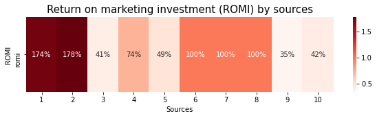

```python
roi_source['romi'] = roi_source['arpu'] / roi_source['cac']
roi_heat = roi_source[['source_id','romi']]
roi_heat = roi_heat.replace([np.inf, -np.inf], np.nan)
roi_heat = roi_heat.fillna(1)
roi_heat = roi_heat.set_index('source_id')
plt.figure(figsize=(10,2))
sns.heatmap(roi_heat.T, cmap='Reds', annot=True, fmt='.0%')
plt.title('Return on marketing investment (ROMI) by sources', fontdict={'size':15})
plt.ylabel('ROMI')
plt.xlabel('Sources')
plt.show()
```

ROMI less than 100 percent means that the investment did not pay off, but more than 100% that it paid off.  
ROMI for sources 1 and 2 is positive (174% and 178%), that is, the costs have paid off and a profit was made (74% and 78%). For sources 6 - 8, there were no costs, but revenue was received, so I conditionally designated the profitability as 100%.

```python
# Study ROMI per sourses
romi_sources_months = orders.groupby(['source_id', 'buy_month']).agg({'uid':'nunique', 'revenue':'sum'}).reset_index()
romi_sources_months.columns=['source_id', 'month', 'n_customers', 'revenue']
romi_sources_months['arpu'] = romi_sources_months['revenue'] / romi_sources_months['n_customers']
```

```python
costs_sources_months = costs.groupby(['source_id', 'month_costs'])['costs'].sum()
costs_sources_months = costs_sources_months.rename_axis(index={'month_costs': 'month'})
romi_sources_months = romi_sources_months.join(costs_sources_months, on=['source_id', 'month'])
```

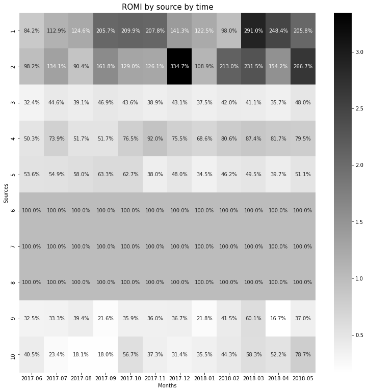

```python
romi_sources_months['cac'] = romi_sources_months['costs'] / romi_sources_months['n_customers']
romi_sources_months['romi'] = romi_sources_months['arpu'] / romi_sources_months['cac']
romi_sources_months_pivot = romi_sources_months.pivot_table(index='month', columns='source_id',
                                                            values='romi', aggfunc='sum')
romi_sources_months_pivot[[6,7,8]] = romi_sources_months_pivot[[6,7,8]].replace(0,1)
plt.figure(figsize=(13,13))
sns.heatmap(romi_sources_months_pivot.T, cmap='binary', annot=True, fmt='.1%')
plt.title('ROMI by source by time', fontsize = '15')
plt.ylabel('Sources')
plt.xlabel('Months')
plt.show()
```

```python
# Study ROMI per cohorts
romi_cohort_months = orders.groupby(['cohort', 'buy_month']).agg({'revenue':'sum'}).reset_index()
romi_cohort_months.columns=['cohort', 'month', 'revenue']
romi_cohort_months = romi_cohort_months.join(cohort_cac['n_cohrt_custmrs'], on='cohort')
romi_cohort_months['arpu'] = romi_cohort_months['revenue'] / romi_cohort_months['n_cohrt_custmrs']
costs_cohort_months = costs.groupby(['cohort', 'month_costs'])['costs'].sum()
costs_cohort_months = costs_cohort_months.rename_axis(index={'month_costs': 'month'})
romi_cohort_months = romi_cohort_months.join(costs_cohort_months, on=['cohort', 'month'])
```

```python
romi_cohort_months['cac'] = romi_cohort_months['costs'] / romi_cohort_months['n_cohrt_custmrs']
romi_cohort_months['romi'] = romi_cohort_months['arpu'] / romi_cohort_months['cac']
romi_cohort_months['cum_arpu'] = romi_cohort_months['arpu']
for i in range(1, len(romi_cohort_months)): # Need to repeat because com_arpu.shift() doesn't work without it
    romi_cohort_months['cum_arpu'] = np.where(romi_cohort_months['cac']>0,
                                              romi_cohort_months['arpu'],
                                              romi_cohort_months['arpu'] + romi_cohort_months['cum_arpu'].shift())
romi_cohort_months['fix_cac'] = romi_cohort_months['cac']
for i in range(1, len(romi_cohort_months)):
    romi_cohort_months['fix_cac'] = np.where(romi_cohort_months['cac']>0,
                                      romi_cohort_months['cac'],
                                      romi_cohort_months['fix_cac'].shift())
romi_cohort_months['cum_romi'] = romi_cohort_months['cum_arpu'] / romi_cohort_months['fix_cac']

romi_sources_cohort_pivot = romi_cohort_months.pivot_table(index='month', columns='cohort',
                                                            values='cum_romi', aggfunc='sum')
```

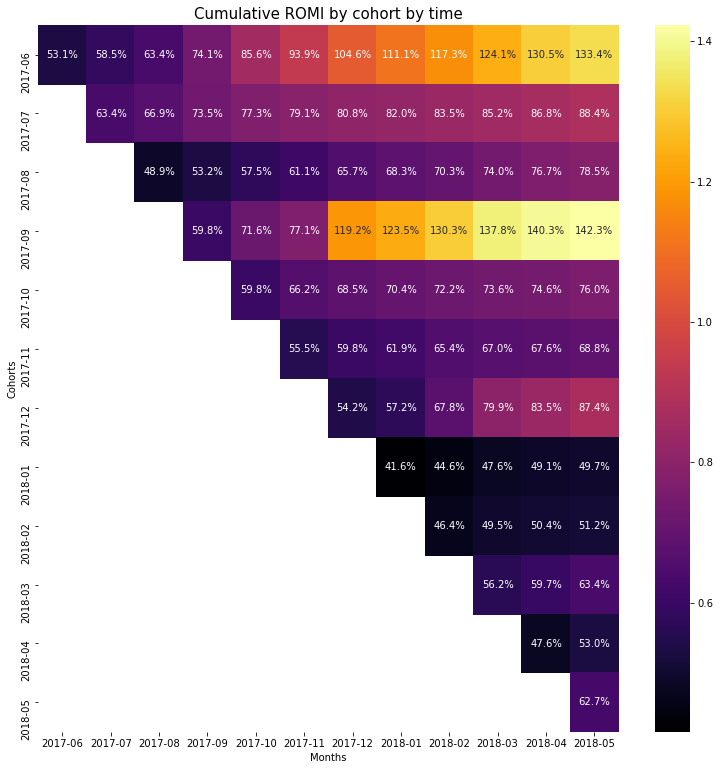

```python
plt.figure(figsize=(13,13))
sns.heatmap(romi_sources_cohort_pivot.T, cmap='inferno', annot=True, fmt='.1%')
plt.title('Cumulative ROMI by cohort by time', fontsize = '15')
plt.ylabel('Cohorts')
plt.xlabel('Months')
plt.show()
```

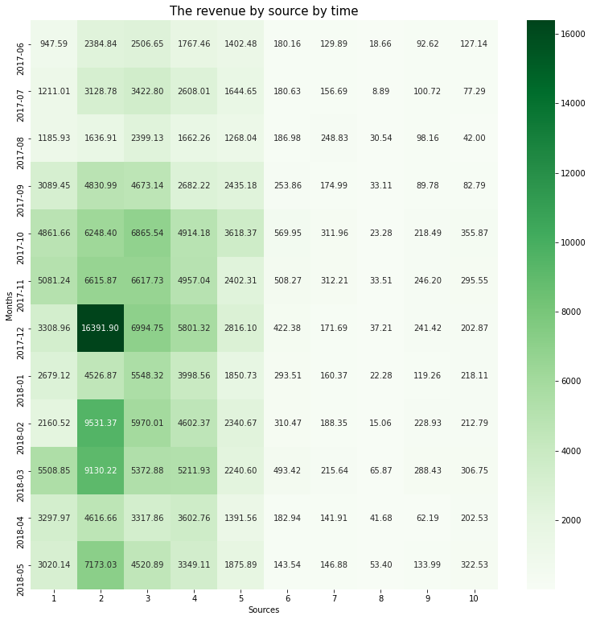

```python
# Study how much money bring an each of the channels.
revenue_per_source_months = orders.pivot_table(index='buy_month', columns='source_id',
                                           values='revenue', aggfunc='sum')
plt.figure(figsize=(13,13))
sns.heatmap(revenue_per_source_months, cmap='Greens', annot=True, fmt='.2f')
plt.title('The revenue by source by time', fontsize = '15')
plt.ylabel('Months')
plt.xlabel('Sources')
plt.show()
```

The heatmap confirms the revenue leadership of sources 2 and 3, and also shows the impact of the season on sales. During the summer months, there is a clear decline in sales.

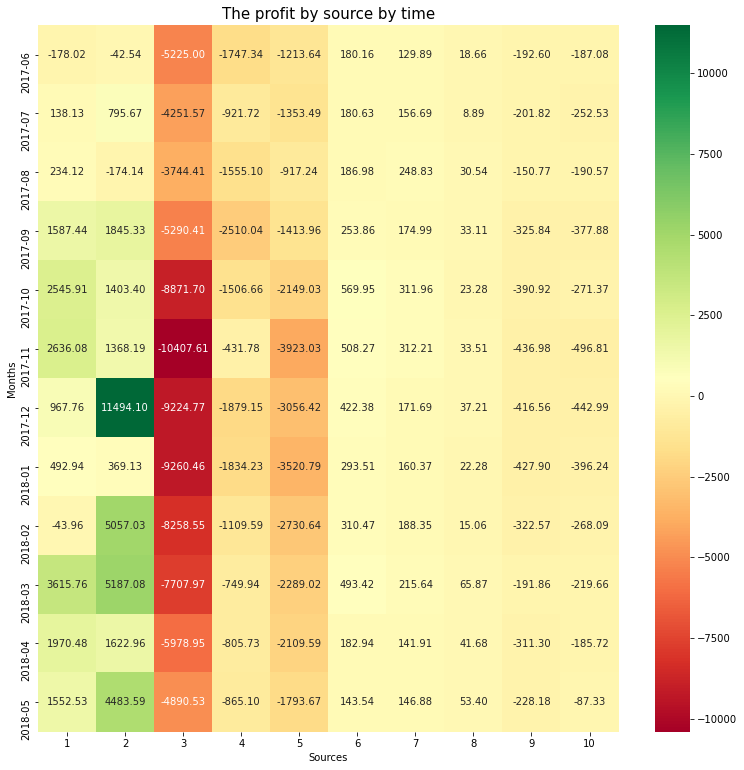

```python
# Calculate the profit and show result by heatmap
profit_per_source_month = revenue_per_source_months - costs_month_per_source
profit_per_source_month[6]=revenue_per_source_months[6] # add missing columns
profit_per_source_month[7]=revenue_per_source_months[7]
profit_per_source_month[8]=revenue_per_source_months[8]

plt.figure(figsize=(13,13))
sns.heatmap(profit_per_source_month, cmap='RdYlGn', annot=True, fmt='.2f')
plt.title('The profit by source by time', fontsize = '15')
plt.ylabel('Months')
plt.xlabel('Sources')
plt.show()
```

As we saw earlier, sources 1 and 2 are the leaders in profitability. 3rd source shows the biggest losses.

```python
report_months = orders.groupby('buy_month')['revenue'].sum().reset_index()
report_months = report_months.rename(columns={'buy_month':'month'})
costs_source = costs.groupby('month_costs')['costs'].sum()
report_months = report_months.join(costs_source, on='month')
report_months = report_months.fillna(0)
report_months['profit'] = report_months['revenue'] - report_months['costs']
report_months = report_months.set_index('month')
```

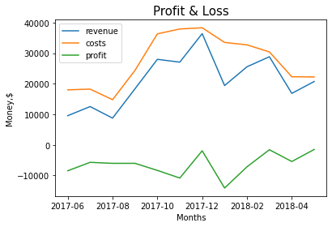

```python
plt.figure(figsize=(8, 14))

report_months.plot()
plt.title('Profit & Loss', fontdict={'size':15})
plt.xlabel('Months')
plt.ylabel('Money,$')
plt.show()
```

```python
report_months['cum_profit'] = report_months['profit'].cumsum()
report_months.loc['total']=([report_months['revenue'].sum(), report_months['costs'].sum(),
                                 report_months['profit'].sum(), '-'])
report_months['romi']=report_months['revenue'] / report_months['costs']
report_months.round(2).T
```

| month | 2017-06 | 2017-07 | 2017-08 | 2017-09 | 2017-10 | 2017-11 | 2017-12 | 2018-01 | 2018-02 | 2018-03 | 2018-04 | 2018-05 | total |
| --- | --- | --- | --- | --- | --- | --- | --- | --- | --- | --- | --- | --- | --- |
| revenue | 9557.49 | 12539.5 | 8758.78 | 18345.5 | 27987.7 | 27069.9 | 36388.6 | 19417.1 | 25560.5 | 28834.6 | 16858.1 | 20739.4 | 252057 |
| costs | 18015 | 18240.6 | 14790.5 | 24368.9 | 36322.9 | 37907.9 | 38315.3 | 33518.5 | 32723 | 30415.3 | 22289.4 | 22224.3 | 329132 |
| profit | -8457.51 | -5701.12 | -6031.76 | -6023.4 | -8335.18 | -10838 | -1926.75 | -14101.4 | -7162.49 | -1580.68 | -5431.32 | -1484.87 | -77074.4 |
| cum_profit | -8457.51 | -14158.6 | -20190.4 | -26213.8 | -34549 | -45386.9 | -47313.7 | -61415.1 | -68577.6 | -70158.2 | -75589.6 | -77074.4 | - |
| romi | 0.53 | 0.69 | 0.59 | 0.75 | 0.77 | 0.71 | 0.95 | 0.58 | 0.78 | 0.95 | 0.76 | 0.93 | 0.77 |

A more familiar visualization model for financiers. Financial result of the year - loss $77074.4

```python
# Study how the revenue differ for various devices.
user_device = visits.groupby('uid')['device'].first()
```

```python
orders = orders.join(user_device, on='uid')
```

```python
revenue_per_device = orders.groupby('device').agg({'uid':'nunique', 'revenue':'sum'}).reset_index()
revenue_per_device = revenue_per_device.rename(columns={'uid':'n_customers', 'revenue':'total_revenue'})
revenue_per_device['arpu'] = (revenue_per_device['total_revenue']
                                             / revenue_per_device['n_customers']).round(2)
```

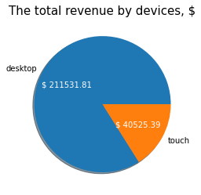

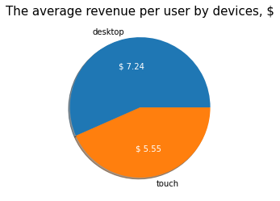

```python
list_m = ['total_revenue', 'arpu']
list_t = ['The total revenue by devices, $', 'The average revenue per user by devices, $']
for m in list_m:
    p, tx, autotexts = plt.pie(revenue_per_device[m],
                           labels= revenue_per_device.device, autopct='', shadow=True)
    for i, a in enumerate(autotexts):
        a.set_text("$ {:.2f}".format(revenue_per_device[m][i]))
        a.set_color(color='white')
    if m==list_m[0]:
        t=list_t[0]
    else:
        t=list_t[1]
    plt.title(t, fontsize=15)
    plt.ylabel("")
    plt.show()
```

Desktop users brought more revenue to the service (\$211531) and, on average, they spend more money on purchases (\\$7,24 per month).